# Exploring Weather Trends

*UDACITY Data Analyst Nanodegree Project* *by Goran Horvat*

*Date: 20.04.2020.*

### Extracting data from server thru SQL queries

# SQL database programing language SELECT c.year, c.country, c.city, c.avg_temp as avg_temp_city, g.avg_temp as avg_temp_global FROM city_data c JOIN global_data g USING(year) WHERE (city IN ('Vienna', 'New York','Amsterdam', 'Delhi','Shanghai','Lagos','Sydney'));

### Importing libraries

```python
import numpy as np
import pandas as pd
import matplotlib.pyplot as plt
import seaborn as sns
sns.set(style='whitegrid')
```

### Loading data and basic exploration

```python
data = pd.read_csv('query_7_cities.csv')
data.shape
```

```
(1521, 5)
```

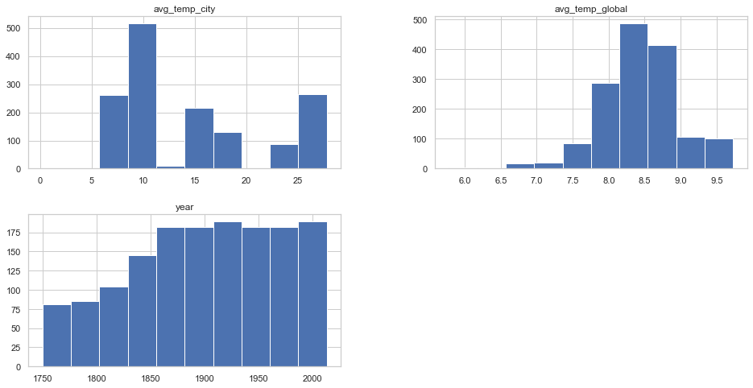

```python
data.hist(figsize=(16,8));
```

```python
print('We have '+ str(data['city'].nunique()) + ' unique cities in observation:')
print (list(data['city'].unique()))
```

```
We have 7 unique cities in observation:
['Amsterdam', 'Delhi', 'Lagos', 'New York', 'Shanghai', 'Sydney', 'Vienna']
```

### Selecting nearby citiy - Vienna (Wien), Austria

In this Exploring of Weather Trend my nearby city is Vienna in Austria and therefore I'll explore data for this one. Others cities which I'll include in this exploration are :

- Amsterdam, Delhi, Lagos, New York, Shanghai and Sydney

This cities are places around the world, that we can observe tempereture and correlation with global changes on different places.

```python
df_vienna = data[data['city']=='Vienna'].copy()
df_vienna.reset_index(drop=True, inplace = True)
```

```python
df_vienna.describe()
```

|  | year | avg_temp_city | avg_temp_global |
| --- | --- | --- | --- |
| count | 264.000000 | 264.000000 | 264.000000 |
| mean | 1881.500000 | 8.042083 | 8.359394 |
| std | 76.354437 | 0.846756 | 0.575184 |
| min | 1750.000000 | 3.420000 | 5.780000 |
| 25% | 1815.750000 | 7.507500 | 8.077500 |
| 50% | 1881.500000 | 8.075000 | 8.365000 |
| 75% | 1947.250000 | 8.592500 | 8.700000 |
| max | 2013.000000 | 10.080000 | 9.730000 |

```python
print ('Range of obsevation per years for Vienna !')
print ('Minimal year in dataset: ' + str(df_vienna['year'].min()))
print ('Maximal year in dataset: ' + str(df_vienna['year'].max()))
print ('We observe range of ' + str(df_vienna['year'].max()-df_vienna['year'].min()) + ' years in our dataset')
```

```
Range of obsevation per years for Vienna !
Minimal year in dataset: 1750
Maximal year in dataset: 2013
We observe range of 263 years in our dataset
```

```python
print ('Minimal avg. tem. in Vienna: ' + str(df_vienna['avg_temp_city'].min()))
print ('Maximal avg. tem. in Vienna: ' + str(df_vienna['avg_temp_city'].max()))
print ('Difference in avg. temp. in Vienna in dataset: ' + str(df_vienna['avg_temp_city'].max() - df_vienna['avg_temp_city'].min()))
```

```
Minimal avg. tem. in Vienna: 3.42
Maximal avg. tem. in Vienna: 10.08
Difference in avg. temp. in Vienna in dataset: 6.66
```

### Average temperature per year - Vienna vs Global

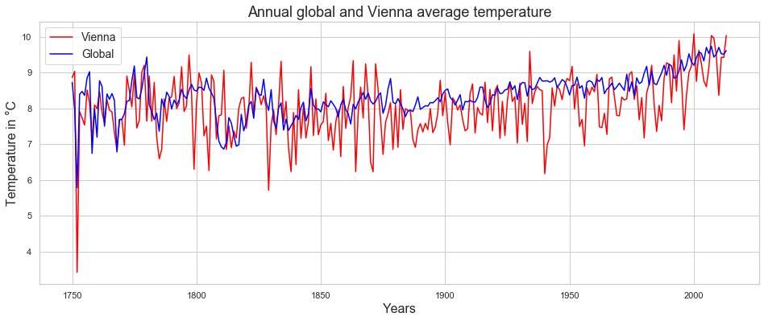

```python
dim=(16,6)
fig, ax = plt.subplots(1,1, figsize=dim)

sns.lineplot('year','avg_temp_city', data = df_vienna, label = 'Vienna', color = 'red')
sns.lineplot('year','avg_temp_global', data = df_vienna, label = 'Global', color = 'blue')

plt.title ('Annual global and Vienna average temperature', fontsize=18)
plt.xlabel ('Years', fontsize=16)
plt.ylabel ('Temperature in °C', fontsize=16)
plt.legend(loc=2, fontsize = 14)
plt.show()
```

```python
print ('Annual average temperature for period from 1752 to 2013 for World and Vienna was:')
print ('1.) World  : {:0.2f}'.format( df_vienna['avg_temp_global'].mean() ) )
print ('2.) Vienna : {:0.2f}'.format( df_vienna['avg_temp_city'].mean() ) )
```

```
Annual average temperature for period from 1752 to 2013 for World and Vienna was:
1.) World  : 8.36
2.) Vienna : 8.04
```

   Observations:
   - Vienna has bigger oscilation in average annual temperature then world
   - Coldest year in Vienna was in 1752 with 3,42°C, and lowest global temperatur was also that year with 5,78°C
   - There are much more oscilation in temperature in Vienna then on global level
   - After 1900 we see increasing of temperature trend

### Calculating moving averages for desired city

Q: Question:

- Which window time for moving averages will be the adequate for presentation that we can draw conclusions.  
  Let's see charts for world and city data (Vienna) with 'window' of 2, 10, 50 and 100 years.

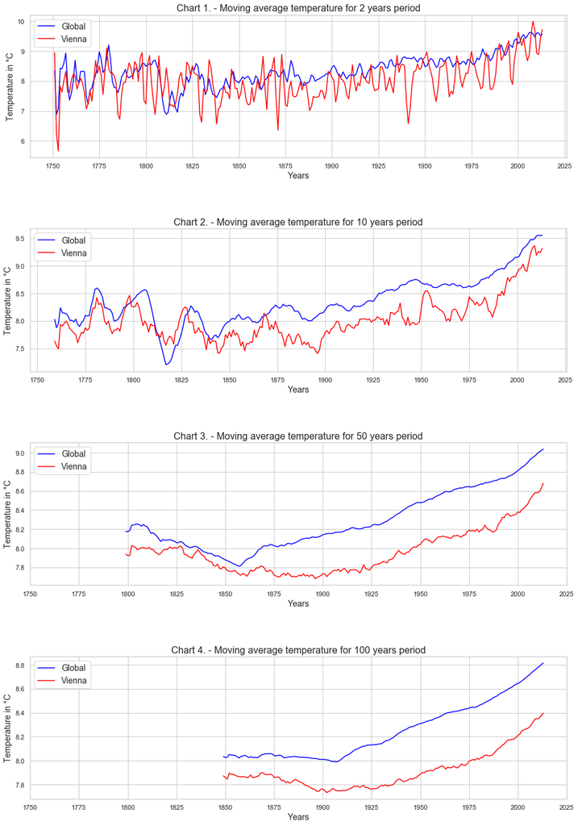

```python
ma_win =[2,10,50,100] # moving average windows

dim=(16,6*len(ma_win))
fig, ax = plt.subplots(len(ma_win),1, figsize=dim)
plt.subplots_adjust(hspace=0.5)

for y in range(len(ma_win)):
    df_vienna['ma_global_' + str(ma_win[y])]= np.nan
    for x in range(len(df_vienna)-ma_win[y]+1):
        df_vienna['ma_global_' + str(ma_win[y])] = df_vienna['avg_temp_global'].rolling(window=ma_win[y]).mean()   # mov.avg.
        df_vienna['ma_city_' + str(ma_win[y])] = df_vienna['avg_temp_city'].rolling(window=ma_win[y]).mean()       # mov.avg.

    a = df_vienna.index[ma_win[y]-1]
    data_set = df_vienna.loc[a:,:]
    p1 = sns.lineplot('year','ma_global_' + str(ma_win[y]), data = data_set, label = 'Global', color = 'blue', ax=ax[y])
    p1 = sns.lineplot('year','ma_city_' + str(ma_win[y]), data = data_set, label = 'Vienna', color = 'red', ax=ax[y])

    ax[y].set_title ( 'Chart ' + str(y+1) + '. - Moving average temperature for ' + str(ma_win[y]) + ' years period',
                     fontsize=16)
    ax[y].set_xlabel ('Years', fontsize=14)
    ax[y].set_ylabel ('Temperature in °C', fontsize=14)
    range_y= range(1750, 2026, 25 )
    p1.set(xticks=range_y)
    ax[y].legend(loc=2, fontsize = 14)
plt.show()
```

Observations for:

```
* 1. chart - data are more dense and it's not easy to read trends.
* 2. chart - by window 10 for mov. avg. we can see groups of period in time and it's easy to conclude also the trends.
* 3. chart and 4. chart
           - give us a picture that from 1752 until 1860 we have decreasing in temperature both for world and Vienna.
             After 1860 global temperature had increased for both observation and riseing almost paralell with
             difference around 0.4°C more on side of global temperatur.
```

I decide to use moving average period of 10 years, because they give us a balans of smooth line and showing us a fluctuation of temperature on timeline.  
Temperature trend with 100 years moving average tell us that from until 1914 are more or less flat trend, and then starts growing trend which is till today. For temperature trend with moving average of 150 or 200 years period this dataset is to small beacuse we become more or less flatt line for short period of time 40-90 years

### Making a line chart: World temperature vs Vienna temperature

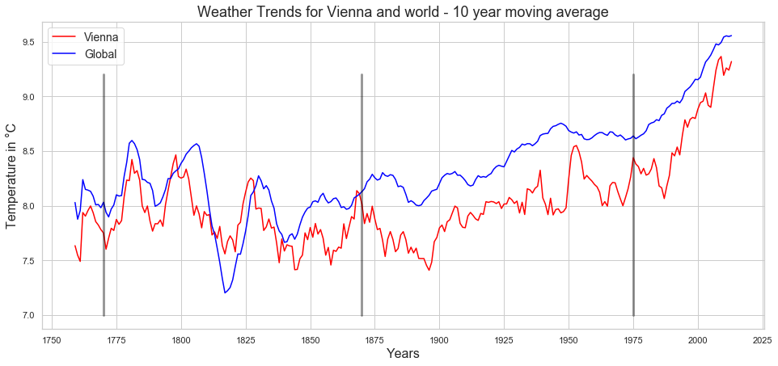

```python
dim=(16,7)
fig, ax = plt.subplots(1,1, figsize=dim)

data_set = df_vienna.loc[9:,:]
p1 = sns.lineplot('year','ma_city_10', data = data_set, label = 'Vienna', color = 'red')
p1 = sns.lineplot('year','ma_global_10', data = data_set, label = 'Global', color = 'blue')

plt.title ('Weather Trends for Vienna and world - 10 year moving average', fontsize=18)
plt.xlabel ('Years', fontsize=16)
plt.ylabel ('Temperature in °C', fontsize=16)
plt.legend(loc=2, fontsize = 14)

plt.plot([1770,1770],[7.0,9.2], color='black', alpha=0.4, lw=3)
plt.plot([1870,1870],[7.0,9.2], color='black', alpha=0.4, lw=3)
plt.plot([1975,1975],[7.0,9.2], color='black', alpha=0.4, lw=3)

range_y= range(1750, 2026, 25 )
p1.set(xticks=range_y)

plt.show()
```

```python
diff1 = df_vienna.loc[df_vienna['year'] < 1870,'ma_global_10'].mean() - df_vienna.loc[df_vienna['year'] < 1870,'ma_city_10'].mean()
diff2 = df_vienna.loc[df_vienna['year'] > 1870,'ma_global_10'].mean() - df_vienna.loc[df_vienna['year'] > 1870,'ma_city_10'].mean()
diff3 = df_vienna.loc[df_vienna['year'] > 1975,'ma_global_10'].mean() - df_vienna.loc[df_vienna['year'] > 1975,'ma_city_10'].mean()

avg1 = df_vienna.loc[df_vienna['year'] < 1870,'ma_global_10'].mean()
avg2 = df_vienna.loc[df_vienna['year'] > 1870,'ma_global_10'].mean()
avg3 = df_vienna.loc[df_vienna['year'] > 1975,'ma_global_10'].mean()

avg1v = df_vienna.loc[df_vienna['year'] < 1870,'ma_city_10'].mean()
avg2v = df_vienna.loc[df_vienna['year'] > 1870,'ma_city_10'].mean()
avg3v = df_vienna.loc[df_vienna['year'] > 1975,'ma_city_10'].mean()

df_report = pd.DataFrame([[diff1,avg1,avg1v], [diff2,avg2,avg2v], [diff3,avg3,avg3v]],
                         columns = ['difference', 'global average', 'Vienna average'],
                         index = ['1750 - 1870','1870 - 2013', '1975 - 2013'])
df_report
```

|  | difference | global average | Vienna average |
| --- | --- | --- | --- |
| 1750 - 1870 | 0.171342 | 8.035631 | 7.864288 |
| 1870 - 2013 | 0.435329 | 8.585378 | 8.150049 |
| 1975 - 2013 | 0.378053 | 9.064158 | 8.686105 |

```python
df_vienna.loc[df_vienna['year'] > 1975,'ma_global_10'].mean()
```

```
9.064157894736846
```

###### We can observe that the average temperature line for Vienna follows the global average temperature line

- In this graph we can find the three main parts of the timeline
  1. The first part is from 1750 to 1870 what corresponds with the first industrial revolution all the way to the second
  2. The second part is from 1870 to 1975, this part covers the beginning of the second industrial revolution until the third is started.
  3. The third part is from 1975 to the present days and this corespond with star of third industrial revolution

     ** Graph show us that to 1870 global temperatur and Vienna temperatur are more or less overlaping, while after that global teperatur rise more then Viena temp., and difference is from 0.2 °C to 1.0 °C.

     ** On last part of graph, last 25 years, we see that temperature in Vienna is in consistant increase by higher rate to global temperature.
- We will explore more deeply every of this parts on our timeline

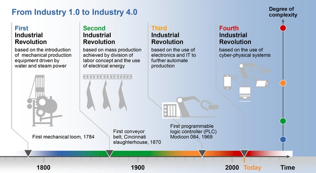

```
                                picture from https://www.tritoninnovation.com/industry40
```

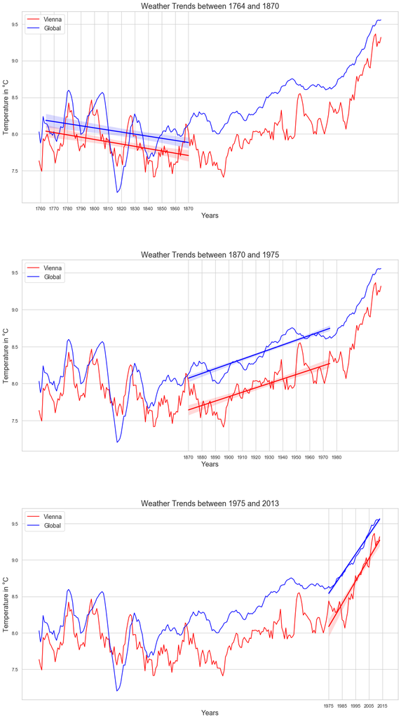

```python
#Line chart with linear regression line between period 1764 to 2013
dim=(16,30)
fig, ax = plt.subplots(3,1, figsize=dim)
plt.subplots_adjust(hspace=0.3)

tline = [[1764,1870],[1870,1975],[1975,2013]]
rline = [[1760,1871,10],[1870,1981,10],[1975,2016,10]]
txline =['Weather Trends between 1764 and 1870',
         'Weather Trends between 1870 and 1975', 'Weather Trends between 1975 and 2013']

for x in range(0,3):

    data_set = df_vienna.loc[9:,:]
    p1 = sns.lineplot('year','ma_city_10', data = data_set, label = 'Vienna', color = 'red', ax=ax[x])
    p1 = sns.lineplot('year','ma_global_10', data = data_set, label = 'Global', color = 'blue', ax=ax[x])

    a = tline[x][0]
    b = tline[x][1]
    a = df_vienna.index[df_vienna['year']==a][0]
    b = df_vienna.index[df_vienna['year']==b][0]
    data_set = df_vienna.loc[a:b,:]
    p1 = sns.regplot('year','ma_city_10', data = data_set,
                color = 'red', scatter_kws={'alpha':0.0, 'linewidth':0.6}, ax=ax[x])
    p1 = sns.regplot('year','ma_global_10', data = data_set,
                color = 'blue', scatter_kws={'alpha':0.0, 'linewidth':0.6}, ax = ax[x])

    ax[x].set_title (txline[x], fontsize=18)
    ax[x].set_xlabel ('Years', fontsize=16)
    ax[x].set_ylabel ('Temperature in °C', fontsize=16)

    range_y= range(rline[x][0], rline[x][1], rline[x][2])
    p1.set(xticks=range_y)
    ax[x].legend(loc=2, fontsize = 14)

plt.show()
```

- On every chart from above it's clear that average temprature in Vienna more or less follow the World average temperature
  1. when we observe timeline for complete data we can say that the trend is growing But, we don't have data before year 1752 and we can't see what was trens for previous years or centuries
  2. From 1750 until 1840 the both temperature trend are decreasing in values
  3. At the end of 19th century (around year 1870.) started second industrial revolution and huge use od steam engines and mass production. From there until year 1975 is growing trend of temperature in Vienna and world, and after 1975 trend is even more increasinig

### Exploration of other cities around the World

```python
data.groupby('city').describe().T
```

|  | city | Amsterdam | Delhi | Lagos | New York | Shanghai | Sydney | Vienna |
| --- | --- | --- | --- | --- | --- | --- | --- | --- |
| year | count | 264.000000 | 218.000000 | 165.000000 | 264.000000 | 173.000000 | 173.000000 | 264.000000 |
|  | mean | 1881.500000 | 1904.500000 | 1931.000000 | 1881.500000 | 1927.000000 | 1927.000000 | 1881.500000 |
|  | std | 76.354437 | 63.075352 | 47.775517 | 76.354437 | 50.084928 | 50.084928 | 76.354437 |
|  | min | 1750.000000 | 1796.000000 | 1849.000000 | 1750.000000 | 1841.000000 | 1841.000000 | 1750.000000 |
|  | 25% | 1815.750000 | 1850.250000 | 1890.000000 | 1815.750000 | 1884.000000 | 1884.000000 | 1815.750000 |
|  | 50% | 1881.500000 | 1904.500000 | 1931.000000 | 1881.500000 | 1927.000000 | 1927.000000 | 1881.500000 |
|  | 75% | 1947.250000 | 1958.750000 | 1972.000000 | 1947.250000 | 1970.000000 | 1970.000000 | 1947.250000 |
|  | max | 2013.000000 | 2013.000000 | 2013.000000 | 2013.000000 | 2013.000000 | 2013.000000 | 2013.000000 |
| avg_temp_city | count | 264.000000 | 201.000000 | 151.000000 | 263.000000 | 173.000000 | 173.000000 | 264.000000 |
|  | mean | 9.131288 | 25.166269 | 26.553113 | 9.486882 | 15.973237 | 17.004220 | 8.042083 |
|  | std | 0.770730 | 0.594003 | 0.542227 | 1.099282 | 0.575494 | 0.432598 | 0.846756 |
|  | min | 5.970000 | 23.700000 | 24.860000 | 0.250000 | 14.470000 | 16.080000 | 3.420000 |
|  | 25% | 8.640000 | 24.800000 | 26.195000 | 9.070000 | 15.600000 | 16.720000 | 7.507500 |
|  | 50% | 9.140000 | 25.140000 | 26.660000 | 9.550000 | 15.930000 | 16.940000 | 8.075000 |
|  | 75% | 9.632500 | 25.550000 | 26.920000 | 10.025000 | 16.230000 | 17.260000 | 8.592500 |
|  | max | 11.040000 | 26.710000 | 27.790000 | 12.160000 | 17.860000 | 18.180000 | 10.080000 |
| avg_temp_global | count | 264.000000 | 218.000000 | 165.000000 | 264.000000 | 173.000000 | 173.000000 | 264.000000 |
|  | mean | 8.359394 | 8.403532 | 8.554545 | 8.359394 | 8.528902 | 8.528902 | 8.359394 |
|  | std | 0.575184 | 0.548662 | 0.460165 | 0.575184 | 0.467894 | 0.467894 | 0.575184 |
|  | min | 5.780000 | 6.860000 | 7.560000 | 5.780000 | 7.560000 | 7.560000 | 5.780000 |
|  | 25% | 8.077500 | 8.092500 | 8.190000 | 8.077500 | 8.180000 | 8.180000 | 8.077500 |
|  | 50% | 8.365000 | 8.415000 | 8.530000 | 8.365000 | 8.520000 | 8.520000 | 8.365000 |
|  | 75% | 8.700000 | 8.727500 | 8.770000 | 8.700000 | 8.760000 | 8.760000 | 8.700000 |
|  | max | 9.730000 | 9.730000 | 9.730000 | 9.730000 | 9.730000 | 9.730000 | 9.730000 |

```python
df_cities = data.copy()

for city in data['city'].unique():

    ranges = len(data.loc[data['city']==city,:])
    for x in range(ranges-10+1):
        df_cities.loc[data['city']==city,'ma_global'] = \
                data.loc[data['city']==city,'avg_temp_global'].rolling(window=10).mean()

        df_cities.loc[data['city']==city,'ma_city'] = \
                data.loc[data['city']==city,'avg_temp_city'].rolling(window=10).mean()
```

```python
pd.options.display.max_rows = 100
df_cities.tail(5)
```

|  | year | country | city | avg_temp_city | avg_temp_global | ma_global | ma_city |
| --- | --- | --- | --- | --- | --- | --- | --- |
| 1516 | 2009 | Austria | Vienna | 9.48 | 9.51 | 9.493 | 9.365 |
| 1517 | 2010 | Austria | Vienna | 8.36 | 9.70 | 9.543 | 9.193 |
| 1518 | 2011 | Austria | Vienna | 9.42 | 9.52 | 9.554 | 9.260 |
| 1519 | 2012 | Austria | Vienna | 9.42 | 9.51 | 9.548 | 9.240 |
| 1520 | 2013 | Austria | Vienna | 10.03 | 9.61 | 9.556 | 9.319 |

```python
print('We have '+ str(data['city'].nunique()) + ' unique cities in observation:')
print (list(data['city'].unique()))
```

```
We have 7 unique cities in observation:
['Amsterdam', 'Delhi', 'Lagos', 'New York', 'Shanghai', 'Sydney', 'Vienna']
```

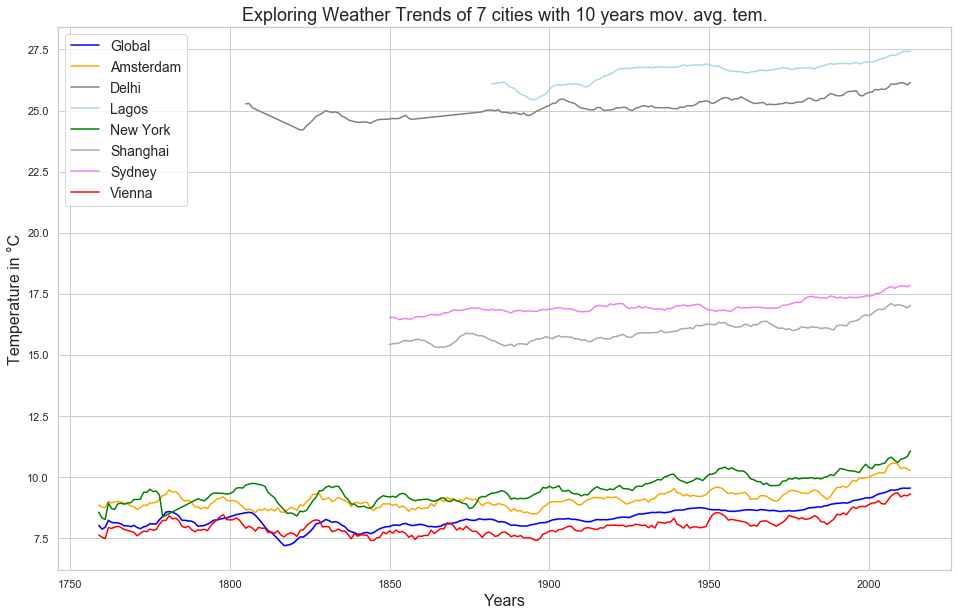

```python
dim=(16,10)
fig, ax = plt.subplots(1,1, figsize=dim)


sns.lineplot('year','ma_global', data =
             df_cities.loc[9:,:], label = 'Global', color = 'blue', )

sns.lineplot('year','ma_city', data =
             df_cities.loc[df_cities['city']=='Amsterdam',:], label = 'Amsterdam', color = 'orange')

sns.lineplot('year','ma_city', data =
             df_cities.loc[df_cities['city']=='Delhi',:], label = 'Delhi', color = 'gray')

sns.lineplot('year','ma_city', data =
             df_cities.loc[df_cities['city']=='Lagos',:], label = 'Lagos', color = 'lightblue')

sns.lineplot('year','ma_city', data =
             df_cities.loc[df_cities['city']=='New York',:], label = 'New York', color = 'green')

sns.lineplot('year','ma_city', data =
             df_cities.loc[df_cities['city']=='Shanghai',:], label = 'Shanghai', color = 'darkgray')

sns.lineplot('year','ma_city', data =
             df_cities.loc[df_cities['city']=='Sydney',:], label = 'Sydney', color = 'violet')

sns.lineplot('year','ma_city', data =
             df_cities.loc[df_cities['city']=='Vienna',:], label = 'Vienna', color = 'red')

plt.title ('Exploring Weather Trends of 7 cities with 10 years mov. avg. tem.', fontsize=18)
plt.xlabel ('Years', fontsize=16)
plt.ylabel ('Temperature in °C', fontsize=16)
plt.legend(loc=2, fontsize = 14)
plt.show()
```

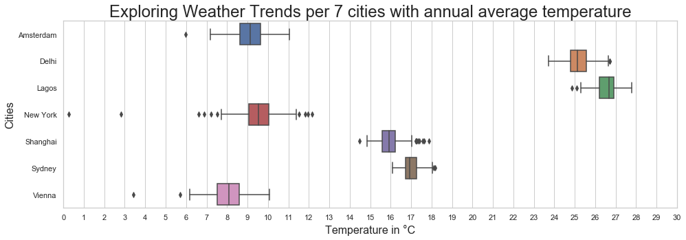

```python
dim=(16,5)
fig, ax = plt.subplots(1,1, figsize=dim)

sns.boxplot(y='city', x='avg_temp_city',data=df_cities)

plt.title ('Exploring Weather Trends per 7 cities with annual average temperature', fontsize=24)
plt.ylabel ('Cities', fontsize=16)
plt.xlabel ('Temperature in °C', fontsize=16)
plt.xlim (0,30)
ranges = range(0,31,1)
plt.xticks(ranges)
plt.show()
```

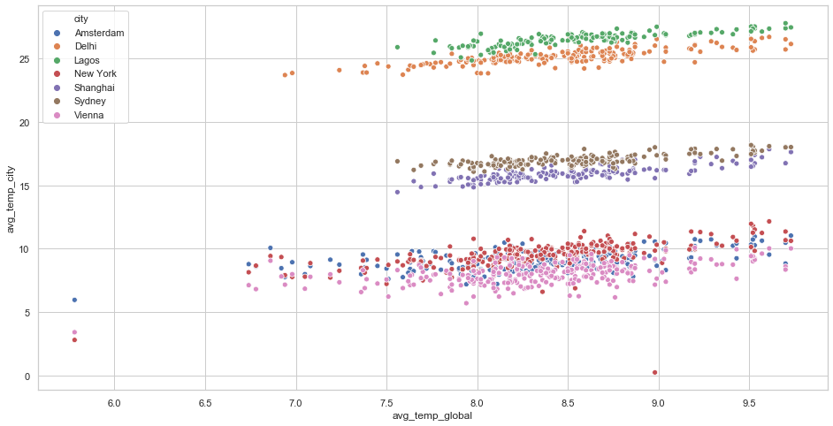

```python
plt.figure(figsize=(16,8))
sns.scatterplot(x='avg_temp_global', y='avg_temp_city', hue= 'city', data=df_cities);
```

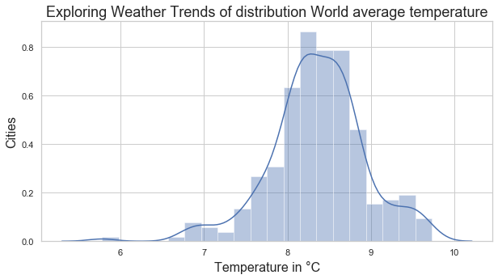

```python
dim=(10,5)
fig, ax = plt.subplots(1,1, figsize=dim)

sns.distplot(df_cities[df_cities['city']=='Vienna']['avg_temp_global'], bins=20)

plt.title ('Exploring Weather Trends of distribution World average temperature', fontsize=18)
plt.ylabel ('Cities', fontsize=16)
plt.xlabel ('Temperature in °C', fontsize=16)
plt.show()
```

```python
df_cities.groupby('city')['avg_temp_city', 'avg_temp_global', 'ma_global', 'ma_city'].mean()
```

| city | avg_temp_city | avg_temp_global | ma_global | ma_city |
| --- | --- | --- | --- | --- |
| Amsterdam | 9.131288 | 8.359394 | 8.344286 | 9.120475 |
| Delhi | 25.166269 | 8.403532 | 8.376301 | 25.184799 |
| Lagos | 26.553113 | 8.554545 | 8.539974 | 26.583242 |
| New York | 9.486882 | 8.359394 | 8.344286 | 9.519963 |
| Shanghai | 15.973237 | 8.528902 | 8.516006 | 15.961793 |
| Sydney | 17.004220 | 8.528902 | 8.516006 | 16.992713 |
| Vienna | 8.042083 | 8.359394 | 8.344286 | 8.025133 |

### Correlation coefficient

```python
df_cities.groupby('city')['avg_temp_global', 'avg_temp_city'].corr()
```

| city |  | avg_temp_global | avg_temp_city |
| --- | --- | --- | --- |
| Amsterdam | avg_temp_global | 1.000000 | 0.516804 |
|  | avg_temp_city | 0.516804 | 1.000000 |
| Delhi | avg_temp_global | 1.000000 | 0.762654 |
|  | avg_temp_city | 0.762654 | 1.000000 |
| Lagos | avg_temp_global | 1.000000 | 0.814152 |
|  | avg_temp_city | 0.814152 | 1.000000 |
| New York | avg_temp_global | 1.000000 | 0.563413 |
|  | avg_temp_city | 0.563413 | 1.000000 |
| Shanghai | avg_temp_global | 1.000000 | 0.784995 |
|  | avg_temp_city | 0.784995 | 1.000000 |
| Sydney | avg_temp_global | 1.000000 | 0.754343 |
|  | avg_temp_city | 0.754343 | 1.000000 |
| Vienna | avg_temp_global | 1.000000 | 0.534342 |
|  | avg_temp_city | 0.534342 | 1.000000 |

```python
df_vienna
```

|  | year | country | city | avg_temp_city | avg_temp_global | ma_global_2 | ma_city_2 | ma_global_10 | ma_city_10 | ma_global_50 | ma_city_50 | ma_global_100 | ma_city_100 |
| --- | --- | --- | --- | --- | --- | --- | --- | --- | --- | --- | --- | --- | --- |
| 0 | 1750 | Austria | Vienna | 8.86 | 8.72 | NaN | NaN | NaN | NaN | NaN | NaN | NaN | NaN |
| 1 | 1751 | Austria | Vienna | 9.03 | 7.98 | 8.350 | 8.945 | NaN | NaN | NaN | NaN | NaN | NaN |
| 2 | 1752 | Austria | Vienna | 3.42 | 5.78 | 6.880 | 6.225 | NaN | NaN | NaN | NaN | NaN | NaN |
| 3 | 1753 | Austria | Vienna | 7.91 | 8.39 | 7.085 | 5.665 | NaN | NaN | NaN | NaN | NaN | NaN |
| 4 | 1754 | Austria | Vienna | 7.73 | 8.47 | 8.430 | 7.820 | NaN | NaN | NaN | NaN | NaN | NaN |
| ... | ... | ... | ... | ... | ... | ... | ... | ... | ... | ... | ... | ... | ... |
| 259 | 2009 | Austria | Vienna | 9.48 | 9.51 | 9.470 | 9.720 | 9.493 | 9.365 | 8.9706 | 8.5828 | 8.7616 | 8.3498 |
| 260 | 2010 | Austria | Vienna | 8.36 | 9.70 | 9.605 | 8.920 | 9.543 | 9.193 | 8.9930 | 8.5808 | 8.7764 | 8.3494 |
| 261 | 2011 | Austria | Vienna | 9.42 | 9.52 | 9.610 | 8.890 | 9.554 | 9.260 | 9.0074 | 8.5902 | 8.7898 | 8.3568 |
| 262 | 2012 | Austria | Vienna | 9.42 | 9.51 | 9.515 | 9.420 | 9.548 | 9.240 | 9.0226 | 8.6290 | 8.8032 | 8.3779 |
| 263 | 2013 | Austria | Vienna | 10.03 | 9.61 | 9.560 | 9.725 | 9.556 | 9.319 | 9.0376 | 8.6804 | 8.8163 | 8.3980 |

264 rows × 13 columns

```python
df_vienna.loc[:,['avg_temp_city','avg_temp_global']].corr()
```

|  | avg_temp_city | avg_temp_global |
| --- | --- | --- |
| avg_temp_city | 1.000000 | 0.534342 |
| avg_temp_global | 0.534342 | 1.000000 |